# k-Centres Riemannian Functional Clustering (kCRFC)

2022-01-27

# Data Generation on 2-dimensional Sphere

## Data generation

> Dai, X., & Müller, H. G. (2018). Principal component analysis for functional data on Riemannian manifolds and spheres. The Annals of Statistics, 46(6B), 3334-3361.
- Dai et al.(2018) 에서 meanfunction의 형태와 PC score의 variance만 바꿔서 시뮬레이션 진행 (paper 22 page 참고)
- True PC score의 variance와 meanfunction의 2번째 axis 형태를 다음과 같이 바꾼 형태로 진행
  - **Case 1**
    - $\xi_k \sim N(0, (1+0.07)^{k/2})$
    - $-0.3\pi\sin(\pi t)$
  - **Case 2**
    - $\xi_k \sim N(0, (1+0.07)^{k/2})$
    - $0.3\pi\cos(4\pi t)$
  - **Case 3**
    - $\xi_k \sim N(0, (1+0.07)^{k/2})$
    - $0.3\pi\sin(3\pi t)$

## Data example

- **Top Left** : Meanfunction of Case 1 + individual curves
- **Top Right** : Meanfunction of Case 1
- **Bottom Left** : Meanfunction of Case 2
- **Bottom Right** : Meanfunction of Case 3

[interactive chart not shown]

# Clustering Results

- `fdapace`에 있는 `kCFC()` 함수에서의 FPCA 부분을 RFPCA로 바꾸어 진행

## Case 1

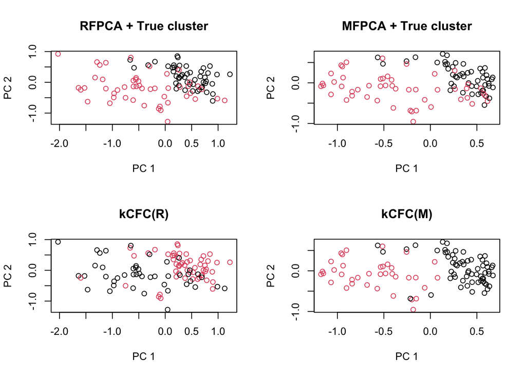

```
## CCR - kCFC(R) : 0.95
```

```
## CCR - kCFC(M) : 0.87
```

## Case 2

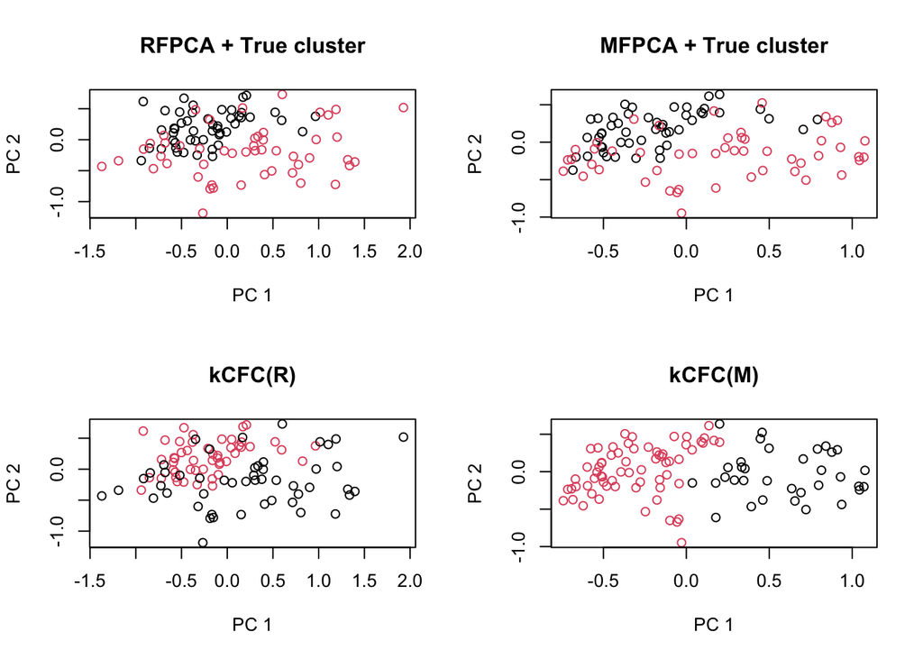

```
## CCR - kCFC(R) : 1
```

```
## CCR - kCFC(M) : 0.74
```

## Case 3

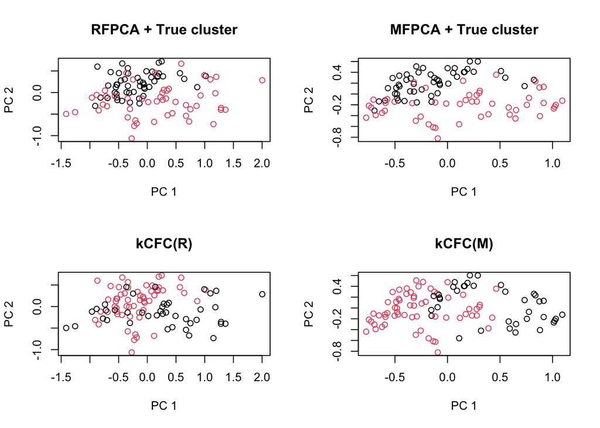

```
## CCR - kCFC(R) : 0.92
```

```
## CCR - kCFC(M) : 0.53
```

## Result from 30 repetitons

- **CCR** : Correct Classification Rate
- **aRand** : adjusted Rand index

  | Method | Case 1 CCR | Case 1 aRand | Case 2 CCR | Case 2 aRand | Case 3 CCR | Case 3 aRand |
  | --- | --- | --- | --- | --- | --- | --- |
  | kCFC(R) | 0.886 (0.095) | 0.627 (0.257) | 0.856 (0.140) | 0.579 (0.334) | 0.828 (0.151) | 0.514 (0.350) |
  | kCFC(M) | 0.869 (0.075) | 0.563 (0.210) | 0.678 (0.110) | 0.166 (0.182) | 0.584 (0.058) | 0.032 (0.048) |
  | K-means(R) | 0.815 (0.049) | 0.402 (0.120) | 0.650 (0.064) | 0.098 (0.073) | 0.604 (0.063) | 0.049 (0.058) |
  | K-means(M) | 0.818 (0.054) | 0.410 (0.135) | 0.652 (0.070) | 0.103 (0.091) | 0.587 (0.057) | 0.033 (0.044) |

# Conclusion

- Clustering이나 classification 목적으로 sphere(또는 manifold)에서 functional data를 generate하는 reference가 없어서, 우선 임의로 mean의 형태만 다르게 하여 테스트 (관련 reference가 있는지 더 찾아봐야할 듯)
- 여기서 MFPCA라고 한 부분이 정확한 MFPCA인지 확인이 필요 (Exponential map을 Euclidean metric으로 계산한 것을 MFPCA라고 생각했는데 확인해봐야할 듯)
- Clustering 결과에서 standard error가 다소 큰 편임
  - 간혹 몇 개 결과에서 CCR이 0.5 ~ 0.6 정도로 매우 안좋아지는 경우가 종종 발생
  - 현재 initial FPCA에서 FVE = 0.9, iteration에서의 FPCA FVE = 0.7로 두고 한 결과이지만, 모두 0.9로 두고 한 경우에도 CCR이 크게 나빠지는 경우가 발생함